# Act_Report

By: Bilal Almajnooni

## Analyzing and Visualizing the master dataset

```python
df_final.describe()
```

|  | rating_numerator | rating_denominator | confidence_percentage | favorite_count | retweet_count |
| --- | --- | --- | --- | --- | --- |
| count | 1994.000000 | 1994.000000 | 1686.000000 | 1994.000000 | 1994.000000 |
| mean | 12.280843 | 10.532096 | 0.549936 | 8895.725677 | 2766.753260 |
| std | 41.497718 | 7.320710 | 0.299270 | 12213.193181 | 4674.698447 |
| min | 0.000000 | 2.000000 | 0.000010 | 81.000000 | 16.000000 |
| 25% | 10.000000 | 10.000000 | 0.302892 | 1982.000000 | 624.750000 |
| 50% | 11.000000 | 10.000000 | 0.550604 | 4136.000000 | 1359.500000 |
| 75% | 12.000000 | 10.000000 | 0.821962 | 11308.000000 | 3220.000000 |
| max | 1776.000000 | 170.000000 | 0.999956 | 132810.000000 | 79515.000000 |

```python
df_final[df_final.favorite_count == 132810]
```

|  | tweet_id | timestamp | text | rating_numerator | rating_denominator | name | dog_stage | jpg_url | dog_breed | confidence_percentage | favorite_count | retweet_count |
| --- | --- | --- | --- | --- | --- | --- | --- | --- | --- | --- | --- | --- |
| 1977 | 822872901745569793 | 2017-01-21 18:26:02 | Here's a super supportive puppo participating ... | 13 | 10 | NaN | puppo | https://pbs.twimg.com/media/C2tugXLXgAArJO4.jpg | Lakeland_terrier | 0.196015 | 132810 | 48265 |

```python
df_final[df_final.favorite_count == 132810].text.iloc[0]
```

```
"Here's a super supportive puppo participating in the Toronto  #WomensMarch today. 13/10 https://t.co/nTz3FtorBc"
```

And for the most retweeted tweet:

```python
df_final[df_final.retweet_count == 79515]
```

|  | tweet_id | timestamp | text | rating_numerator | rating_denominator | name | dog_stage | jpg_url | dog_breed | confidence_percentage | favorite_count | retweet_count |
| --- | --- | --- | --- | --- | --- | --- | --- | --- | --- | --- | --- | --- |
| 1727 | 744234799360020481 | 2016-06-18 18:26:18 | Here's a doggo realizing you can stand in a po... | 13 | 10 | NaN | doggo | https://pbs.twimg.com/ext_tw_video_thumb/74423... | Labrador_retriever | 0.825333 | 131075 | 79515 |

```python
df_final[df_final.retweet_count == 79515].text.iloc[0]
```

```
"Here's a doggo realizing you can stand in a pool. 13/10 enlightened af (vid by Tina Conrad) https://t.co/7wE9LTEXC4"
```

Sadly, we don't have their names, but atleast we know which breed they are. Lakeland Terrier and Labrador Retriever

```python
df_final.dog_breed.value_counts()
```

```
nan                            308
golden_retriever               158
Labrador_retriever             108
Pembroke                        95
Chihuahua                       91
pug                             62
toy_poodle                      51
chow                            48
Samoyed                         42
Pomeranian                      42
malamute                        33
Chesapeake_Bay_retriever        31
French_bulldog                  31
cocker_spaniel                  30
miniature_pinscher              25
Eskimo_dog                      22
Staffordshire_bullterrier       21
German_shepherd                 21
Cardigan                        21
Shih-Tzu                        20
Siberian_husky                  20
beagle                          20
Maltese_dog                     19
Rottweiler                      19
Shetland_sheepdog               19
Lakeland_terrier                18
kuvasz                          18
basset                          17
Italian_greyhound               17
West_Highland_white_terrier     16
                              ...
Saluki                           4
keeshond                         4
bluetick                         4
Gordon_setter                    4
Rhodesian_ridgeback              4
Weimaraner                       4
curly-coated_retriever           3
Afghan_hound                     3
Leonberg                         3
briard                           3
toy_terrier                      3
cairn                            3
Irish_water_spaniel              3
Greater_Swiss_Mountain_dog       3
Brabancon_griffon                3
komondor                         3
Appenzeller                      2
wire-haired_fox_terrier          2
black-and-tan_coonhound          2
Australian_terrier               2
groenendael                      2
Sussex_spaniel                   2
standard_schnauzer               1
Bouvier_des_Flandres             1
EntleBucher                      1
Japanese_spaniel                 1
silky_terrier                    1
Scotch_terrier                   1
clumber                          1
Irish_wolfhound                  1
Name: dog_breed, Length: 114, dtype: int64
```

Looks like the Retriever bloodline are on top of the list of the most popular dog breeds with Golden Retriever and Labrador Retriever.

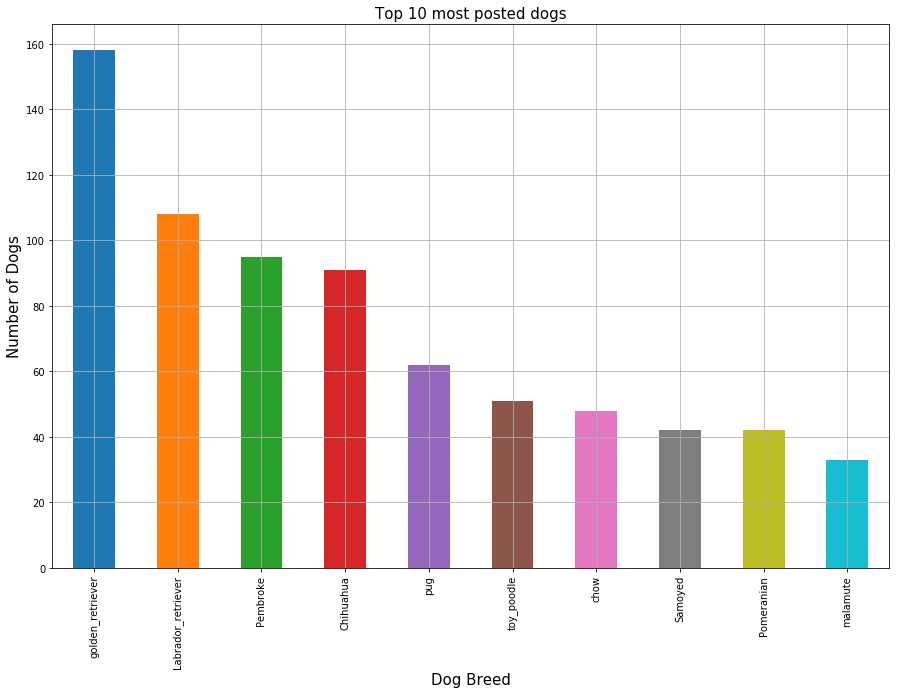

```python
insight = df_final.groupby('dog_breed')['dog_breed'].count().sort_values(ascending=False)[1:11]
insight.plot(kind='bar',figsize=(15,10))
plt.title('Top 10 most posted dogs', fontsize= 15)
plt.xlabel('Dog Breed', fontsize= 15);
plt.ylabel('Number of Dogs', fontsize= 15);
plt.grid()
```

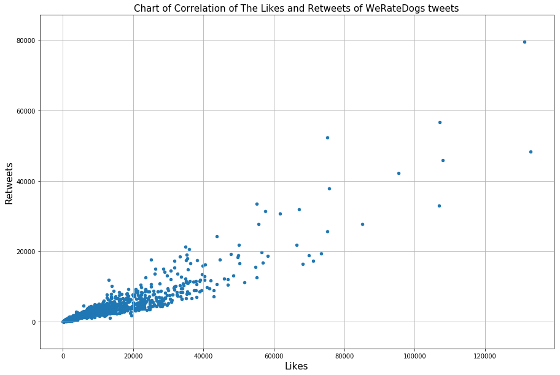

```python
df_final.plot(x='favorite_count',y='retweet_count',kind='scatter',figsize=(15,10))
plt.title('Chart of Correlation of The Likes and Retweets of WeRateDogs tweets', fontsize= 15);
plt.xlabel('Likes', fontsize= 15);
plt.ylabel('Retweets', fontsize= 15);
plt.axis('equal');
plt.grid();
```

Looks like most of the tweets made has more likes than retweets. Having a positive correlation of likes and retweets for a dog rating account seems convincing.

Now let's look at how many tweets are posted weekly:

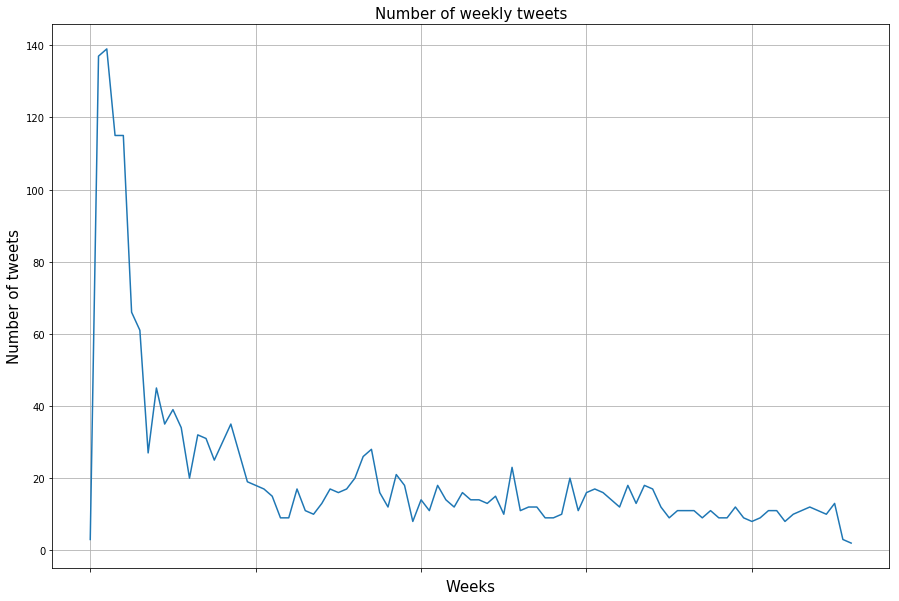

```python
finsight = df_final.timestamp.groupby([df_final.timestamp.dt.year, df_final.timestamp.dt.week]).count()
finsight.plot(kind='line',figsize=(15,10));
plt.title('Number of weekly tweets', fontsize= 15);
plt.xlabel('Weeks', fontsize= 15);
plt.ylabel('Number of tweets', fontsize= 15);
plt.grid();
```

```python
finsight.mean()
```

```
21.440860215053764
```

It seems that the first few weeks of the dataset had higher number of tweets compared to the rest of the timeline. Having about 21 tweets per week, we could say that everyday they post an average of 3 tweets per day, which is pretty active.